# KNN: K-Nearest Neighbors (for classification)

K-nearest neighbors (KNN) is a classification method that attempts to estimate the conditional distribution of the observations (e.g. vector $Y$) given a set of features (matrix $\mathbf{X}$):

$$Pr(Y=j|X=x_0) = \frac{1}{K} \sum_{i \in \mathcal{N}_0} I(y_i=j)$$

Let’s look at this:

- $K$ is the chosen **number of neighbors** to consider
- $x_0$ is the **observation** we want to classify (we have features but not know the class it belongs to)
- $\mathcal{N}_0$ is such neighborhood of $x_0$
- $I(y_i=j)$ is the number of neighbors in $\mathcal{N}_0$ belonging to class $j$

The observation $x_0$ is then classified to the class with the largest probability (“Bayes rule”).

## Distance function

A crucial aspect in KNN classification is of course how you *define the distance* between observations. A common choice is the Euclidean distance, which basically takes the square root of the sum of **squared differences in feature values** between any two points:

1. Euclidean distance:

$$D_E(x_i,x_j) = \sqrt{ \sum_{m=1}^M (x_{i,m}-x_{j,m})^2 }$$

The Euclidean distance, though, is designed for **continuous features**, and is therefore not very suited for categorical features. Luckily, other distance functions exist for **categorical features**, like the Hamming distance function:

2. Hamming distance (categorical features):

$$D_H(x_i,x_j) = \frac{1}{M} \sum_{m=1}^M I(x_{i,m} \neq x_{j,m})$$

In this brief practical/demonstration, we’ll go through an illustration of how to apply KNN to the problem of imputing missing SNP genotypes in rice (*Oryza sativa*).

1. Raw data
2. Introduce (artificial) missing genotypes
3. Imputation with R package
4. Step by step KNN imputation: write our own code!

### The dataset

We’ll be using SNP genotype data from 12 samples genotyped with the “**GeneChip Rice 44K SNP**”.

```
##         name chr   pos strand snp100715Plate8-B01-IT7 snp100715Plate8-B02-IT12
## 1: dd1000009   1 70143      +                      AA                       AA
## 2: dd1000015   1 70150      +                      AA                       AA
## 3: dd1000022   1 70157      +                      AA                       AA
## 4: dd1000032   1 70162      +                      AA                       AA
## 5: dd1000036   1 70169      +                      AA                       AA
## 6: dd1000051   1 70180      +                      AA                       AA
##    snp100715Plate8-B03-IT13 snp100715Plate8-B04-IT14 snp100715Plate8-B05-IT20
## 1:                       AA                       AA                       AA
## 2:                       AA                       AA                       AA
## 3:                       AA                       AA                       AA
## 4:                       AA                       AA                       AA
## 5:                       AA                       AA                       AA
## 6:                       AA                       AA                       AA
##    snp100715Plate8-B06-IT32 snp100715Plate8-B07-IT38 snp100715Plate8-B08-IT55
```

[output cut: 20 more lines]

```
## [1] 40080
```

```
## [1] 16
```

```r
oldcode <- c("AA","BB","--")
neucode <- c(-1,1,NA)

M0 <- apply(rice44[,5:ncol(rice44)],2,function(x) neucode[match(x,oldcode)])
head(M0)
```

```
##      snp100715Plate8-B01-IT7 snp100715Plate8-B02-IT12 snp100715Plate8-B03-IT13
## [1,]                      -1                       -1                       -1
## [2,]                      -1                       -1                       -1
## [3,]                      -1                       -1                       -1
## [4,]                      -1                       -1                       -1
## [5,]                      -1                       -1                       -1
## [6,]                      -1                       -1                       -1
##      snp100715Plate8-B04-IT14 snp100715Plate8-B05-IT20 snp100715Plate8-B06-IT32
## [1,]                       -1                       -1                        1
## [2,]                       -1                       -1                       NA
## [3,]                       -1                       -1                       -1
## [4,]                       -1                       -1                        1
## [5,]                       -1                       -1                        1
## [6,]                       -1                       -1                       NA
##      snp100715Plate8-B07-IT38 snp100715Plate8-B08-IT55 snp100715Plate8-B09-IT68
## [1,]                       -1                       -1                       NA
## [2,]                       -1                       -1                       -1
## [3,]                       -1                       -1                       -1
## [4,]                       -1                       -1                       -1
## [5,]                       -1                       -1                        1
## [6,]                       -1                       -1                       -1
##      snp100715Plate8-B10-IT88 snp100715Plate8-B11-IT92 snp100715Plate8-B12-IT97
## [1,]                       -1                       -1                       -1
## [2,]                       -1                       -1                       -1
## [3,]                       -1                       -1                       -1
## [4,]                       -1                       -1                       -1
## [5,]                       -1                       -1                       -1
## [6,]                       -1                       -1                       -1
```

A summary of the total missing rate in the data is given below:

```r
missingRate <- apply(M0,1,function(x) length(x[is.na(x)])/length(x))
summary(missingRate)
```

```
##    Min. 1st Qu.  Median    Mean 3rd Qu.    Max.
## 0.00000 0.00000 0.00000 0.03241 0.00000 1.00000
```

```r
n_missing <- sum(colSums(is.na(M0))) ## n. of missing genotypes
data_size <- nrow(M0)*ncol(M0)

missing_rate <- n_missing/data_size
print(missing_rate)
```

```
## [1] 0.03241018
```

```r
M <- M0[missingRate==0,]
colnames(M) <- paste("sample",seq(1:ncol(M)),sep="_")
vec <- (rowMeans(M) > -0.8 & rowMeans(M) < 0.8)
M <- M[vec,]
nrow(M)
```

```
## [1] 8609
```

All real missing data are edited out of the dataset. This leavs 8609 SNP. For the sake of the exercise, initially a much smaller subset with 100 SNPs is extracted.

```r
vec <- sample(x = nrow(M), size = 100)
Mreduced <- t(M[vec,])
head(Mreduced)
```

```
##          [,1] [,2] [,3] [,4] [,5] [,6] [,7] [,8] [,9] [,10] [,11] [,12] [,13]
## sample_1   -1   -1    1   -1   -1   -1   -1   -1   -1    -1     1    -1     1
## sample_2   -1   -1    1   -1    1   -1   -1   -1   -1    -1    -1    -1    -1
## sample_3   -1    1   -1   -1    1   -1   -1   -1   -1    -1     1    -1    -1
## sample_4   -1    1   -1   -1   -1   -1   -1   -1   -1    -1    -1    -1    -1
## sample_5   -1   -1    1   -1   -1   -1   -1    1   -1    -1    -1    -1     1
## sample_6    1   -1    1   -1    1    1   -1   -1    1    -1    -1    -1     1
##          [,14] [,15] [,16] [,17] [,18] [,19] [,20] [,21] [,22] [,23] [,24]
## sample_1     1     1    -1    -1    -1    -1    -1    -1    -1    -1     1
## sample_2     1    -1     1    -1    -1    -1    -1    -1     1    -1     1
## sample_3     1    -1     1    -1    -1    -1    -1    -1     1    -1     1
## sample_4    -1    -1    -1    -1    -1    -1    -1    -1    -1     1     1
## sample_5    -1     1    -1    -1    -1    -1    -1    -1    -1    -1     1
## sample_6     1     1     1    -1    -1    -1    -1     1     1    -1    -1
##          [,25] [,26] [,27] [,28] [,29] [,30] [,31] [,32] [,33] [,34] [,35]
## sample_1     1     1    -1    -1     1    -1     1     1    -1     1     1
## sample_2     1    -1    -1    -1    -1    -1    -1    -1    -1    -1    -1
## sample_3     1     1    -1    -1    -1    -1    -1     1    -1     1     1
## sample_4    -1    -1    -1    -1    -1    -1    -1    -1    -1    -1    -1
## sample_5    -1     1     1    -1     1    -1     1     1    -1     1     1
## sample_6     1    -1     1     1     1    -1     1     1    -1    -1    -1
##          [,36] [,37] [,38] [,39] [,40] [,41] [,42] [,43] [,44] [,45] [,46]
## sample_1    -1    -1     1    -1     1    -1     1    -1    -1    -1    -1
## sample_2    -1    -1    -1    -1     1    -1    -1    -1    -1    -1    -1
## sample_3    -1    -1    -1    -1     1    -1     1    -1    -1    -1    -1
## sample_4    -1    -1    -1     1    -1    -1     1    -1     1    -1    -1
## sample_5    -1    -1     1    -1     1    -1     1    -1     1    -1    -1
## sample_6    -1     1    -1     1     1     1     1    -1     1     1    -1
##          [,47] [,48] [,49] [,50] [,51] [,52] [,53] [,54] [,55] [,56] [,57]
## sample_1    -1    -1    -1    -1     1     1    -1    -1    -1    -1     1
## sample_2    -1    -1    -1    -1     1     1    -1    -1     1    -1    -1
## sample_3    -1    -1    -1    -1     1     1    -1    -1    -1    -1    -1
## sample_4    -1    -1    -1    -1    -1    -1    -1    -1    -1    -1    -1
## sample_5    -1    -1    -1    -1     1     1    -1    -1    -1    -1     1
## sample_6     1     1    -1     1     1    -1     1    -1    -1    -1    -1
##          [,58] [,59] [,60] [,61] [,62] [,63] [,64] [,65] [,66] [,67] [,68]
## sample_1    -1    -1    -1    -1     1    -1    -1     1     1    -1     1
## sample_2    -1    -1    -1     1    -1    -1    -1    -1    -1    -1     1
## sample_3    -1    -1    -1    -1     1    -1    -1     1    -1    -1     1
## sample_4    -1    -1    -1    -1    -1    -1    -1    -1    -1    -1    -1
```

[output cut: 8 more lines]

```
## sample_6    -1    -1     1    -1    -1    -1    -1    -1     1     1    -1
##          [,80] [,81] [,82] [,83] [,84] [,85] [,86] [,87] [,88] [,89] [,90]
## sample_1    -1     1    -1    -1    -1    -1     1    -1     1     1     1
## sample_2    -1    -1     1     1    -1    -1     1     1    -1     1    -1
## sample_3    -1     1    -1    -1    -1    -1     1     1    -1     1     1
## sample_4    -1    -1     1    -1    -1    -1    -1    -1    -1    -1    -1
## sample_5    -1     1    -1    -1    -1     1    -1    -1     1     1    -1
## sample_6     1    -1    -1    -1    -1     1    -1     1    -1     1    -1
##          [,91] [,92] [,93] [,94] [,95] [,96] [,97] [,98] [,99] [,100]
## sample_1     1    -1    -1     1    -1    -1     1    -1     1      1
## sample_2    -1    -1    -1     1    -1    -1    -1    -1    -1      1
## sample_3    -1    -1    -1     1    -1    -1    -1    -1    -1     -1
## sample_4    -1    -1    -1    -1    -1    -1    -1    -1    -1      1
## sample_5    -1    -1    -1     1    -1    -1     1    -1     1      1
## sample_6    -1    -1    -1    -1    -1     1     1     1     1      1
```

```r
nSNP <- ncol(Mreduced)
nInd <- nrow(Mreduced)
schwellenWert <- 0.05 # 10% missing data

missing_matrix = matrix(runif(nInd*nSNP), ncol=nSNP)
missing_matrix[missing_matrix < schwellenWert] = NA
missing_matrix[!is.na(missing_matrix)] = 0
injected_data = Mreduced + missing_matrix

artificialMissingRate <- length(injected_data[is.na(injected_data)])/(nInd*nSNP)
print(artificialMissingRate)
```

```
## [1] 0.04333333
```

```r
missing_map = missing_matrix
head(injected_data)
```

```
##          [,1] [,2] [,3] [,4] [,5] [,6] [,7] [,8] [,9] [,10] [,11] [,12] [,13]
## sample_1   -1   -1    1   -1   -1   -1   NA   -1   -1    -1     1    -1     1
## sample_2   -1   -1    1   -1    1   -1   -1   -1   -1    -1    NA    -1    -1
## sample_3   -1    1   -1   NA    1   -1   -1   -1   -1    -1     1    -1    -1
## sample_4   -1    1   -1   -1   -1   -1   -1   -1   -1    -1    -1    -1    -1
## sample_5   -1   -1    1   -1   -1   -1   -1    1   -1    -1    -1    -1     1
## sample_6    1   -1    1   -1    1    1   -1   -1    1    -1    -1    -1     1
##          [,14] [,15] [,16] [,17] [,18] [,19] [,20] [,21] [,22] [,23] [,24]
## sample_1     1     1    NA    -1    -1    -1    -1    -1    -1    -1     1
## sample_2     1    -1     1    -1    -1    -1    -1    -1     1    -1     1
## sample_3     1    -1     1    -1    -1    -1    -1    -1     1    -1     1
## sample_4    -1    -1    -1    -1    -1    -1    -1    -1    -1     1     1
## sample_5    -1     1    -1    -1    -1    -1    -1    -1    -1    -1     1
## sample_6     1     1     1    -1    -1    -1    -1     1     1    -1    -1
##          [,25] [,26] [,27] [,28] [,29] [,30] [,31] [,32] [,33] [,34] [,35]
## sample_1     1     1    -1    -1     1    -1     1     1    -1     1     1
## sample_2     1    -1    -1    -1    -1    -1    -1    -1    -1    -1    -1
## sample_3     1     1    -1    NA    -1    -1    -1     1    -1     1     1
## sample_4    -1    -1    -1    -1    -1    -1    -1    -1    -1    -1    -1
## sample_5    -1     1     1    -1     1    -1     1     1    -1     1     1
## sample_6     1    -1     1     1     1    -1    NA     1    -1    -1    -1
##          [,36] [,37] [,38] [,39] [,40] [,41] [,42] [,43] [,44] [,45] [,46]
## sample_1    -1    -1     1    -1     1    -1     1    -1    -1    -1    -1
## sample_2    -1    -1    -1    -1     1    -1    -1    -1    NA    NA    -1
## sample_3    -1    -1    -1    -1     1    -1     1    -1    -1    -1    -1
## sample_4    -1    -1    -1     1    -1    -1     1    -1     1    -1    -1
## sample_5    -1    -1     1    NA     1    -1     1    -1     1    NA    NA
## sample_6    -1     1    -1     1     1     1     1    -1    NA     1    -1
##          [,47] [,48] [,49] [,50] [,51] [,52] [,53] [,54] [,55] [,56] [,57]
## sample_1    -1    -1    -1    -1     1     1    -1    -1    -1    -1     1
## sample_2    -1    -1    -1    -1    NA     1    -1    -1     1    -1    -1
## sample_3    -1    -1    -1    NA     1     1    -1    -1    -1    -1    -1
## sample_4    -1    -1    -1    -1    -1    -1    -1    -1    -1    -1    -1
## sample_5    -1    NA    -1    -1     1     1    -1    -1    NA    -1     1
## sample_6     1     1    -1     1     1    -1     1    -1    -1    -1    -1
##          [,58] [,59] [,60] [,61] [,62] [,63] [,64] [,65] [,66] [,67] [,68]
## sample_1    -1    -1    -1    -1     1    -1    -1     1     1    -1     1
## sample_2    -1    -1    NA     1    -1    -1    -1    -1    -1    -1     1
## sample_3    -1    -1    -1    -1     1    -1    -1     1    -1    -1     1
## sample_4    -1    -1    -1    -1    -1    -1    -1    -1    -1    -1    -1
```

[output cut: 8 more lines]

```
## sample_6    -1    -1     1    -1    -1    -1    -1    -1     1     1    -1
##          [,80] [,81] [,82] [,83] [,84] [,85] [,86] [,87] [,88] [,89] [,90]
## sample_1    -1     1    -1    -1    -1    -1    NA    -1     1     1     1
## sample_2    -1    -1     1     1    -1    -1     1     1    -1     1    -1
## sample_3    -1     1    -1    -1    -1    -1     1     1    -1     1     1
## sample_4    -1    -1     1    -1    -1    -1    -1    -1    -1    -1    NA
## sample_5    -1     1    -1    -1    -1     1    -1    -1     1     1    -1
## sample_6     1    -1    -1    -1    -1     1    -1     1    -1     1    -1
##          [,91] [,92] [,93] [,94] [,95] [,96] [,97] [,98] [,99] [,100]
## sample_1     1    -1    -1     1    -1    -1     1    -1     1      1
## sample_2    -1    -1    -1     1    -1    -1    -1    -1    -1      1
## sample_3    -1    -1    -1     1    NA    -1    -1    -1    -1     -1
## sample_4    -1    -1    -1    -1    -1    -1    -1    -1    NA      1
## sample_5    -1    -1    -1     1    NA    -1     1    -1     1      1
## sample_6    -1    -1    -1    -1    -1     1     1     1     1      1
```

The current missing rate (in the injected subset) is 0.0433333.

### Step-by-step KNN implementation

Let’s have some fun!!

We’ll now write our own code. Instead of the Euclidean distance function, we will use the **Hamming distance** function, which is better suited for categorical features. SNP genotypes are categorical features (e.g. **AA/AB/BB**).

First, here’s the Hamming distance function:

```r
#calculate distance matrix and nearest neighbours
Hamming <- function(x) {

  z <- matrix(0, nrow = nrow(x), ncol = nrow(x))
  for (k in 1:(nrow(x) - 1)) {
    for (l in (k + 1):nrow(x)) {
      z[k, l] <- sum(x[k, ] != x[l, ], na.rm=TRUE)
      z[l, k] <- z[k, l]
    }
  }
  return(z)
}
```

We choose a small value of $K$ ($K=3$), given the small size of the exercise (and being sure of avoiding the “*curse of dimensionality*” :-)). The objective is to impute missing SNP genotypes at one SNP locus, using all remaining available information (except the target SNP locus).

Let’s have a look at the first elements of the matrix of Hamming distances:

```
##          sample_1 sample_2 sample_3 sample_4 sample_5 sample_6
## sample_1        0       32       19       36       12       43
## sample_2       32        0       19       20       32       41
## sample_3       19       19        0       28       30       42
## sample_4       36       20       28        0       31       45
## sample_5       12       32       30       31        0       42
## sample_6       43       41       42       45       42        0
```

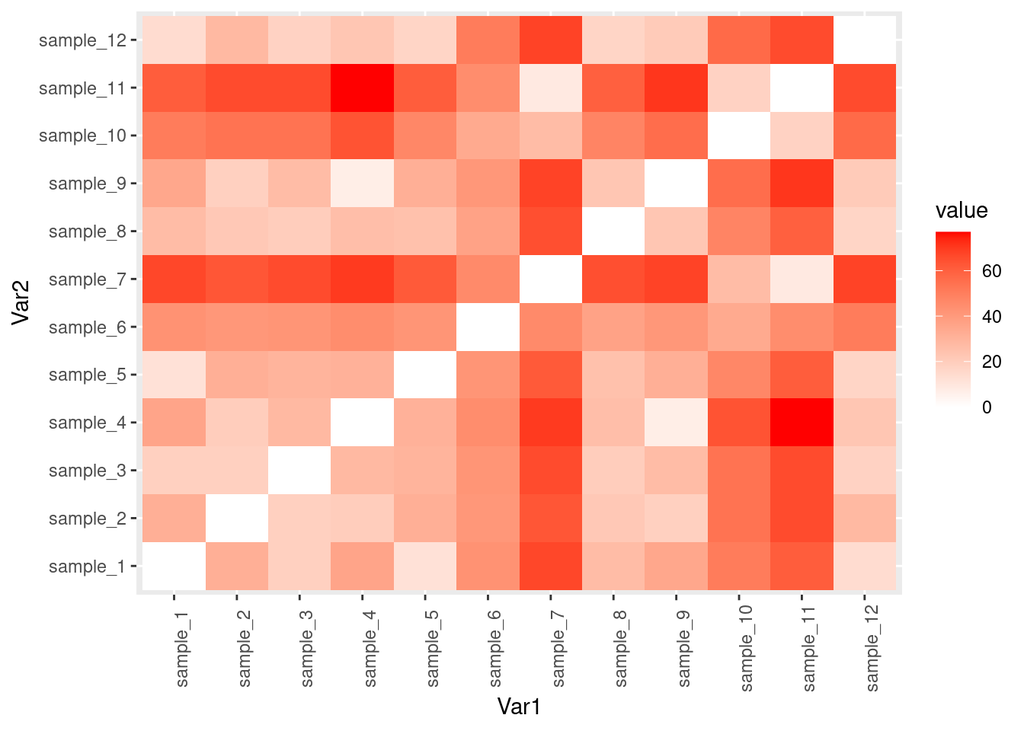

```r
mD <- reshape2::melt(D)

p <- ggplot(mD, aes(x = Var1, y = Var2)) + geom_tile(aes(fill=value))
p <- p + theme(axis.text.x = element_text(angle = 90))
p <- p + scale_fill_gradient2(low="ivory",high = "red")
p
```

This is the vector of SNP genotypes to be imputed: 1, NA, 1, -1, 1, 1, NA, -1, -1, 1, 1, 1.

```r
print(y)
```

```
##  sample_1  sample_2  sample_3  sample_4  sample_5  sample_6  sample_7  sample_8
##         1        NA         1        -1         1         1        NA        -1
##  sample_9 sample_10 sample_11 sample_12
##        -1         1         1         1
```

Non-missing genotypes at this SNP locus are the “*training*” observations, to be used for the imputation of the missing data points. The subset of distances for the missing observations is extracted and ordered by reverse distance (the matrix below is showing, for the test samples, the closest and farthest samples in the training set, orderd from closest to farthest)

```r
testIDS <- names(y[is.na(y)])
trainIDS <- names(y[!is.na(y)])

NN <- apply(D[as.character(testIDS),as.character(trainIDS)],1,order)
NN <- t(NN)

print(NN)
```

```
##          [,1] [,2] [,3] [,4] [,5] [,6] [,7] [,8] [,9] [,10]
## sample_2    2    7    3    6   10    1    4    5    8     9
## sample_7    9    8    5    4    6    2    1    7   10     3
```

We’ll now use KNN to impute the missing genotypes, based on the most frequent genotype in the $K$ neighbors.

```r
ergebnisse <- apply(NN[,1:k, drop=FALSE], 1, function(nn) {
    tab <- table(y[trainIDS][nn]); ## extract k neighbors and compute class frequencies
    maxClass <- names(which.max(tab)) ## get name of most frequent class
    prob <- tab[maxClass]/k; ## calculate probability
    pred <- as.integer(maxClass); ## make prediction
    return(c(pred,prob))
})
```

And these are the results for one single SNP locus:

```r
ergebnisse <- as.data.frame(t(ergebnisse))
names(ergebnisse) <- c("pred","prob")
ergebnisse[ergebnisse$pred==0,]$prob <- 1-ergebnisse[ergebnisse$pred==0,]$prob
print(ergebnisse)
```

[output not shown]

Now we can apply this code to the entire dataset, to impute missing genotypes at all SNP loci.

```r
imputedM <- matrix(rep(NA,nInd*nSNP),nrow=nInd)

for(i in 1:ncol(injected_data)) {

  X <- as.matrix(injected_data[,-i]) #global matrix of features (train + test sets)
  y <- injected_data[,i]
  k <- 3

  if(length(y[is.na(y)])<1) {

    imputedM[,i] <- y
  } else {

    D <- Hamming(X)
    row.names(D) <- names(y)
    colnames(D) <- names(y)

    testIDS <- names(y[is.na(y)])
    trainIDS <- names(y[!is.na(y)])

    if(length(testIDS)!=1) {

      NN <- apply(D[as.character(testIDS),as.character(trainIDS)],1,order)
      NN <- t(NN)
      ids <- row.names(NN) #for the output file

      ergebnisse <- apply(NN[,1:k, drop=F], 1, function(nn) {
        tab <- table(y[trainIDS][nn]);
        maxClass <- names(which.max(tab))
        pred <- as.integer(maxClass);
        return(pred)
      })
      y[testIDS] <- ergebnisse[testIDS]
    } else {

      n <- order(D[testIDS,trainIDS])[1:k]
      tab <- table(y[trainIDS][n]);
      maxClass <- names(which.max(tab))
      prob <- tab[maxClass]/k;
      pred <- as.integer(maxClass);
      y[testIDS] <- pred
    }

    imputedM[,i] <- y
  }
}

#Accuracy of imputation
results <- imputedM[is.na(missing_map)]==Mreduced[is.na(missing_map)]
accuracy <- length(results[results==TRUE])/length(results)
print(accuracy)
```

```
## [1] 0.8076923
```

The accuracy of imputation with the our R code is: **0.8076923**

### Imputation with tidymodels

We’ll now impute missing genotypes using **KNN** with the `tidymodels` R library.

```r
missing_data <- as.data.frame(injected_data)

imputation_recipe <- recipe(missing_data) %>%
  update_role(all_numeric(), new_role = "predictor") %>%
  step_knnimpute(all_predictors(), neighbors = 3)

imputation_recipe_prep <- prep(imputation_recipe)

imputed <- bake(imputation_recipe_prep, missing_data)
imputed2 = juice(imputation_recipe_prep)

head(imputed)
```

```
## # A tibble: 6 x 100
##      V1    V2    V3    V4    V5    V6    V7    V8    V9   V10    V11   V12   V13
##   <dbl> <dbl> <dbl> <dbl> <dbl> <dbl> <dbl> <dbl> <dbl> <dbl>  <dbl> <dbl> <dbl>
## 1    -1    -1     1    -1    -1    -1    -1    -1    -1    -1  1        -1     1
## 2    -1    -1     1    -1     1    -1    -1    -1    -1    -1 -0.333    -1    -1
## 3    -1     1    -1    -1     1    -1    -1    -1    -1    -1  1        -1    -1
## 4    -1     1    -1    -1    -1    -1    -1    -1    -1    -1 -1        -1    -1
## 5    -1    -1     1    -1    -1    -1    -1     1    -1    -1 -1        -1     1
## 6     1    -1     1    -1     1     1    -1    -1     1    -1 -1        -1     1
## # … with 87 more variables: V14 <dbl>, V15 <dbl>, V16 <dbl>, V17 <dbl>,
## #   V18 <dbl>, V19 <dbl>, V20 <dbl>, V21 <dbl>, V22 <dbl>, V23 <dbl>,
## #   V24 <dbl>, V25 <dbl>, V26 <dbl>, V27 <dbl>, V28 <dbl>, V29 <dbl>,
## #   V30 <dbl>, V31 <dbl>, V32 <dbl>, V33 <dbl>, V34 <dbl>, V35 <dbl>,
## #   V36 <dbl>, V37 <dbl>, V38 <dbl>, V39 <dbl>, V40 <dbl>, V41 <dbl>,
## #   V42 <dbl>, V43 <dbl>, V44 <dbl>, V45 <dbl>, V46 <dbl>, V47 <dbl>,
## #   V48 <dbl>, V49 <dbl>, V50 <dbl>, V51 <dbl>, V52 <dbl>, V53 <dbl>,
## #   V54 <dbl>, V55 <dbl>, V56 <dbl>, V57 <dbl>, V58 <dbl>, V59 <dbl>,
## #   V60 <dbl>, V61 <dbl>, V62 <dbl>, V63 <dbl>, V64 <dbl>, V65 <dbl>,
## #   V66 <dbl>, V67 <dbl>, V68 <dbl>, V69 <dbl>, V70 <dbl>, V71 <dbl>,
## #   V72 <dbl>, V73 <dbl>, V74 <dbl>, V75 <dbl>, V76 <dbl>, V77 <dbl>,
## #   V78 <dbl>, V79 <dbl>, V80 <dbl>, V81 <dbl>, V82 <dbl>, V83 <dbl>,
## #   V84 <dbl>, V85 <dbl>, V86 <dbl>, V87 <dbl>, V88 <dbl>, V89 <dbl>,
## #   V90 <dbl>, V91 <dbl>, V92 <dbl>, V93 <dbl>, V94 <dbl>, V95 <dbl>,
## #   V96 <dbl>, V97 <dbl>, V98 <dbl>, V99 <dbl>, V100 <dbl>
```

```r
results <- imputed[is.na(missing_map)]==Mreduced[is.na(missing_map)]
accuracy <- length(results[results==TRUE])/length(results)
print(accuracy)
```

```
## [1] 0.6346154
```

!! important caveat: the R code shown here is intended for demonstration only, and has not been optimized nor tested for applications !!